# PRÁCTICA 6: Presión hidrostática y ecuación de estado del gas ideal

**Autor responsable:** Víctor Mula Navarro

**Autores**: Pablo Corbalán de Concepción y Víctor Mula Navarro.

**Grupo:** G4 - DTIE.

**Fecha del informe:** 19/03/2026.

## INFORMACIÓN GENERAL DEL LABORATORIO

**Fecha de realización de la práctica:** 12/02/2026.

**Temperatura:** 22.2ºC

**Humedad relativa:** 56%

**Presión:** 1035.8 hPa

# 1. INTRODUCCIÓN Y OBJETIVOS

En esta práctica se pretenden estudiar dos leyes fundamentales de la hidrostática mediante un dispositivo experimental de columna de agua en un tubo en forma de U. El sistema permite analizar cómo varía la presión de una cámara de aire al modificar la altura de la columna de líquido que la delimita, relacionando así las leyes de la hidrostática con el comportamiento macroscópico de los gases.

En particular, el experimento busca profundizar en la relación inversamente proporcional entre el volumen y la presión de un gas cuando la temperatura se mantiene constante, fenómeno descrito por la ley de Boyle-Mariotte. A través de la toma de datos de alturas y volúmenes. Esto nos permitirá calcular propiedades de los gases como el número de moles encerrados o la presión atmosférica local en el laboratorio.

Los principales objetivos de esta práctica son los siguientes:

- Verificar la ley fundamental de la hidrostática para una columna de líquido en equilibrio.
- Comprobar la validez de la ley de Boyle-Mariotte para un gas ideal a temperatura constante.
- Estimar experimentalmente la presión atmosférica ($P_{0}$) del laboratorio mediante un ajuste lineal.
- Determinar el número de moles ($n$) de aire encerrados en el dispositivo experimental.
- Analizar la constancia del producto $PV$ y discutir las fuentes de incertidumbre experimental.

## 2. Marco teórico general

El comportamiento del sistema se rige, en primera instancia, por la ley fundamental de la hidrostática. Esta establece que la diferencia de presión entre dos puntos de una columna de fluido depende de la densidad del mismo y del desnivel de altura, según la expresión:

$$\Delta P = \rho g h \tag{1}$$

Donde $\rho$ es la densidad del fluido, $g$ es la aceleración de la gravedad y $h$ es la altura de la columna. Por otro lado, para el gas encerrado en la bureta, se asume un comportamiento de gas ideal definido por su número de moles $n$, volumen $V$, presión $P$ y temperatura absoluta $T$:

$$PV = nRT \tag{2}$$

A temperatura constante, la ecuación (2) se reduce a la ley de Boyle-Mariotte, indicando que el producto de la presión y el volumen es constante. En nuestro montaje, la presión del aire encerrado $P$ se equilibra con la presión atmosférica $P_{0}$ y la presión hidrostática de la columna de agua de altura $\Delta h$:

$$P = P_{0} + \rho_{a}g\Delta h \tag{4}$$

Combinando las expresiones anteriores, podemos relacionar la inversa del volumen total ($V = V_{b} + V_{0}$) con la diferencia de alturas de los niveles de agua entre los extremos del tubo ($\Delta h = h_{c} - h_{a}$). Esta relación nos permite linealizar el problema para realizar un ajuste por mínimos cuadrados:

$$\frac{1}{V} = \frac{\rho_{a}g}{nRT} \Delta h + \frac{P_{0}}{nRT} \tag{5}$$

Esta ecuación presenta la forma $y = ax + b$, donde la pendiente $a = \rho_{a}g / (nRT)$ nos permite obtener el número de moles $n$, y la ordenada en el origen $b = P_{0} / (nRT)$ facilita el cálculo de la presión atmosférica experimental. Este enfoque integral permite evaluar la precisión del modelo teórico frente a las limitaciones instrumentales y las condiciones reales del laboratorio.

## 3. Montaje experimental y procedimiento seguido

### 3.1 Instrumentos

Para la realización de esta práctica se han empleado diversos instrumentos de medida, diferenciando entre dispositivos analógicos y digitales para el correcto tratamiento de las incertidumbres Tipo B:

- Barómetro digital (resolución $0.1$ hPa).
- Termómetro digital (resulción $0.1$ °C)
- Soporte con regla graduada (resolución $0.1$ cm).
- Bureta de vidrio: (resolución $0.1$ cm³).

[figure not shown]

### 3.2 Procedimiento experimental

El experimento se basa en la ley fundamental de la hidrostática y la ley de Boyle-Mariotte. El protocolo seguido en el laboratorio para la obtención de datos es el siguiente:

En primer lugar hemos registrado la temperatura ambiente y la presión atmosférica del laboratorio mediante los sensores digitales. Con el tubo en U preparado, desplazamos verticalmente el extremo abierto del tubo. Al elevarlo o bajarlo respecto al extremo cerrado, se modifica la presión manométrica ejercida sobre el gas debido a la columna de agua excedente ($\Delta h$). Así, para cada posición de equilibrio, se registran tres valores:

- La altura del nivel de agua en el brazo abierto ($h_{a}$).
- La altura del nivel de agua en el brazo cerrado ($h_{c}$).
- El volumen de aire leído directamente en la escala de la bureta ($V_{b}$).

### 4.1 MEDIDAS DIRECTAS

Recogemos en la siguiente tabla las medidas directas tomadas en el laboratorio $h_a$, $h_c$ y $V_b$:

[output not shown]

A partir de estos datos se procederá al cálculo de las medidas indirectas en los apartados posteriores.

### 4.2 MEDIDAS INDIRECTAS

Los cálculos se han efectuado en el anexo 7.1 Hemos obtenido las siguientes medidas:

[output not shown]

Para determinar la incertidumbre de las magnitudes indirectas, se ha utilizado la fórmula general de propagación de errores para variables independientes. La altura es una resta de dos medidas directas ($h_c - h_a$). La incertidumbre de una suma o resta es la raíz de la suma de los cuadrados de las incertidumbres absolutas, así:

$$u_{\Delta h} = \sqrt{u(h_c)^2 + u(h_a)^2}$$

Al igual que la altura, el volumen total es la suma del volumen del matraz ($V_b$) y el volumen muerto o inicial ($V_0$), por tanto:

$$u_V = \sqrt{u(V_b)^2 + u(V_0)^2}$$

Para la inversa $\frac{1}{V}$, la derivada es $-1/V^2$. Aplicando la propagación:

$$u_{\left(\frac{1}{V}\right)} = \frac{u_V}{V^2}$$

Si consideramos como constantes exactas la densidad del agua y la incertidumbre de la gravedad, para obtener la incertidumbre combinada $u_P$, aplicamos la ley de propagación de incertidumbres:

$$u_P = \sqrt{ \left( \frac{\partial P}{\partial P_0} \right)^2 u_{P_0}^2 + \left( \frac{\partial P}{\partial \Delta h} \right)^2 u_{\Delta h}^2 }$$

Calculamos las derivadas parciales de la presión respecto a las dos magnitudes medidas experimentalmente:

$$\frac{\partial P}{\partial P_0} = 1\quad\quad\frac{\partial P}{\partial \Delta h} = \rho_a g$$

Sustituyendo estas derivadas parciales en la ecuación de la incertidumbre combinada, obtenemos la expresión final utilizada en el análisis de datos:

$$u_P = \sqrt{ u_{P_0}^2 + (\rho_a g \cdot u_{\Delta h})^2 }$$

Finalmente, para calcular la inceertidumbre del producto $PV$ usamos la propagacion de incertidumbres para el producto de sendas variables: $$\frac{u_{PV}}{PV} = \sqrt{\left(\frac{u_P}{P}\right)^2 + \left(\frac{u_V}{V}\right)^2}$$

### 4.3 AJUSTE LINEAL

El ajuste por mínimos cuadrados arroja la siguiente gráfica:

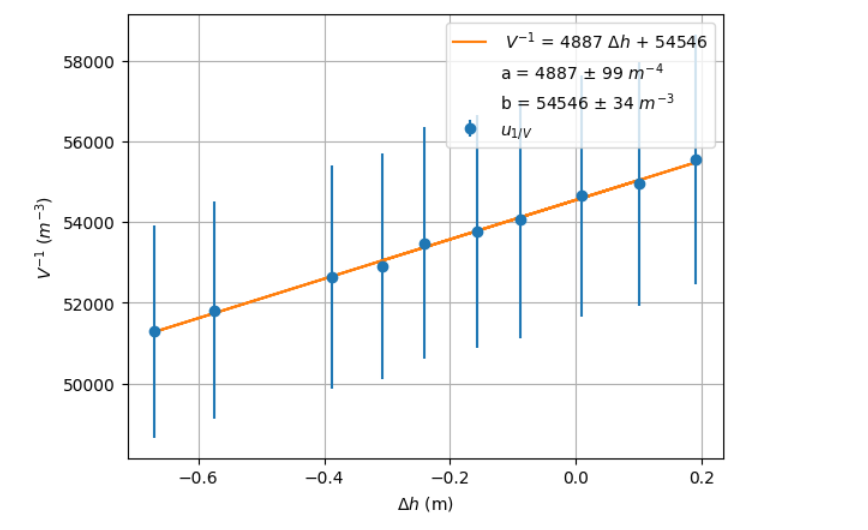

La pendiente $a$ y la ordenada en el origen $b$ obtenidas han sido, con sus respectivas incertidumbres y cifras significativas adecuadas, las siguientes:

$$ a = 4887 \pm 99 \ m^{-4}$$ $$ b = 54546 \pm 34 \ m^{-3}$$

Siguiéndonos de la ecuación ($5$), llegamos a las siguientes expresiones para la pendiente y ordenada en el origen:

$$ a = \frac{\rho_a g}{nRT}$$ $$ b = \frac{P_0}{nRT}$$

#### 4.3.1 OBTENCIÓN DE $n \pm u_n$

De esta forma, podemos determinar el número de moles de gas $n$ que había en la columna así como, posteriormente, la presión $P_0$ del laboratorio. Comencemos con el valor de $n$ y su incertidumbre asociada $u_n$:

$$ n = \frac{\rho_a g}{a\cdot R\cdot T} $$

$$ u_n = n\cdot \sqrt{\left( \frac{u_a}{a} \right)^2 + \left( \frac{u_T}{T} \right)^2}$$

La propagación de incertidumbres nos da esa fórmula pues suponemos $\rho_a$, $g$ y $R$ conocidas con toda la precisión posible. Por tanto, con las cifras significativas adecuadas:

$$ n = 0.000817 \pm 0.000017 \ mol$$

#### 4.3.2 OBTENCIÓN DE $P_0 \pm u_{P_0}$

Para el cálculo de $P_0$:

$$ P_0 = b\cdot n \cdot R \cdot T$$

Si, de la misma forma que antes, suponemos que sólo tenemos incertidumbre en las medidas de $n$, $b$ y $T$, debida esta última a la resolución digital del termómetro del laboratorio, llegamos a la siguiente propagación de incertidumbres:

$$ u_{P_0} = P_0 \cdot \sqrt{\left(\frac{u_n}{n} \right)^2 + \left( \frac{u_b}{b} \right)^2 + \left(\frac{u_T}{T}\right)^2}$$

Si lo expresamos con las cifras significativas correspondientes, concluimos:

$$ P_0 = (1094 \pm 22)\cdot 10^2 \ Pa$$

### 4.4 ECUACIÓN DE ESTADO DEL GAS IDEAL

Procederemos al uso de la ecuación ($2$) para hallar de manera alternativa el número de moles $n$ a partir de la relación:

$$ n = \frac{P \cdot V}{R \cdot T}$$

Tras graficar el número de medidas $i$ frente al valor del producto $P \cdot V$, apreciamos lo siguiente:

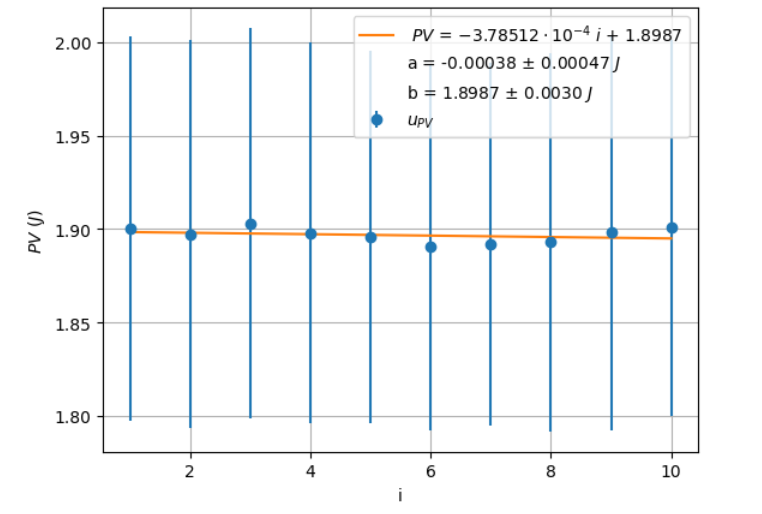

$$ a = -0.00038 \pm 0.00047 \ J$$ $$ b = 1.8987 \pm 0.0030 \ J$$

Reparamos en que $a \approx 0$, por tanto, la gráfica tiene forma de función prácticamente constante. Tomaremos el valor de $b$ como el del producto $P \cdot V$. En consecuencia, de la expresión inmediatamente anterior podemos calcular el número de moles. Si además sacamos también su incertidumbre asociada como:

$$ u_n = n \cdot \sqrt{\left( \frac{u_{P V}}{P V} \right)^2+\left(\frac{u_T}{T}\right)^2} $$

Con las cifras significativas adecuadas, obtenemos mediante esta vía que el número de moles y su incertidumbre asociada tienen el siguiente valor:

$$ n = 0.0007731 \pm 0.0000012 \ mol$$

## 5. CONCLUSIONES

#### 5.1 OBTENCIÓN DEL NÚMERO DE MOLES Y LA PRESIÓN DEL LABORATORIO MEDIANTE REGRESIÓN LINEAL

Haciendo uso de la ecuación ($5$), los valores para $n$ y $P_0$ obtenidos han sido los siguientes:

$$ n = 0.000817 \pm 0.000017 \ mol$$ $$ P_0 = (1094 \pm 22)\cdot 10^2 \ Pa$$

$$ \epsilon_{P_{0}} = \frac{1094 - 1035.8}{1035.8} = 0.0561 = 5.61 \%$$

Valor el cual es aceptable y sugiere que el factor humano en las mediciones de esta práctica no ha influido de manera negativa en la experiencia y las condiciones en las que se presenta el experimento con respecto al marco teórico son adecuadas, puesto que las aproximaciones de primer orden de las fórmulas empleadas así como las suposiciones realizadas acerca del valor constante de la temperatura en el laboratorio han proporcionado resultados fidedignos a las mediciones del instrumento digital.

#### 5.2 VALOR DE $P \cdot V$ Y COMPARACIÓN NÚMERO DE MOLES

Para la segunda parte del experimento, el valor constante para el producto de la presión y el volumen así como el número de moles que se calcula a partir de la fórmula de los gases ideales son los siguientes:

$$ PV = 1.8987 \pm 0.0030 \ J$$ $$ n = 0.0007731 \pm 0.0000012 \ mol$$

De la gráfica obtenida en el apartado $4.4$ y de la tabla de datos del apartado $4.2$, es posible reparar en el hecho de que el producto $PV$ se mantiene prácticamente constante, ya que la pendiente de la gráfica es del orden de $10^{-4}$, lo cual implica que, para el valor de nuestro producto, esa pendiente apenas lo altera. Comprobamos así la validez de la ley de Boyle-Mariotte, la cual afirmaba que $T$ constante $\implies$ $PV$ constante.

Por otro lado, si comparamos el número de moles de aire presentes en la columna de líquido que hemos obtenido por las dos vías anteriores, fijando este último valor como el teórico, llegamos al siguiente valor para el error relativo en la medición de esta magnitud:

$$ \epsilon_n = \frac{0.000817-0.0007731}{0.0007731} = 0.0568 = 5.68 \%$$

Valor muy similar al obtenido en el apartado anterior, que nos dice ambos métodos convergen a un resultado muy parecido. Ello nos permite concluir que las condiciones sobre las que hemos realizado el experimento son adecuadas puesto que hemos sido capaces de llegar a un número de moles prácticamente igual por un método que por el otro.

## 6. Bibliografía

Sears, F. W., Zemansky, M. W., Young, H. D., & Freedman, R. A. (2020). *Física universitaria: Volumen 1* (15.ª ed.). Pearson Education.

Tipler, P. A., & Mosca, G. (2010). *Física para la ciencia y la tecnología: Vol. 1: Mecánica, oscilaciones y ondas, termodinámica* (6.ª ed.). Reverté.

Universidad de Murcia. (2026). *Práctica 6: Presión hidrostática y ecuación de estado del gas ideal*.

## 7. Anexos

### 7.1 Cálculos con Python

Para trabajar con Python importamos las siguientes librerías:

```python
import numpy as np
import matplotlib.pyplot as plt
from scipy.odr import *
```

La siguiente celda recoge las resoluciones y constantes físicas que se usan a lo largo de los cálculos, así como sus incertidumbres asociadas.

```python
temp_celsius = 22.2        # ºC
p0_barometro_hpa = 1035.8  # hPa
rho_a = 1000.0            # kg/m^3
g = 9.81
R = 8.314

res_barometro = 0.1       # hPa
res_termometro = 0.1      # °C
res_regla = 0.1           # cm
res_bureta = 0.1          # cm^3


v0_cm3 = 5.0
u_v0_cm3 = 1.0
u_v0_m3 = u_v0_cm3 * 1e-6

# Conversiones
T_kelvin = temp_celsius + 273.2    # K
P0_bar_pa = p0_barometro_hpa * 100  # Pa
```

```python
# Asumimos distribución rectangular para los aparatos digitales u = resolución / sqrt(12)
# Para los aparatos analógicos asumimos una distribución triangular u = resolución / sqrt(24)
u_P0_bar = (res_barometro * 100) / np.sqrt(12) # Pa
u_T = res_termometro / np.sqrt(12)             # K
u_h = res_regla / np.sqrt(24)                  # cm
u_Vb = res_bureta / np.sqrt(24)                # cm^3
u_Vb_m3 = u_Vb * 1e-6
```

```python
# Medidas experimentales
i = np.array([1, 2, 3, 4, 5, 6, 7, 8, 9, 10])
ha_cm = np.array([39.5, 29.5, 20.2, 46.4, 70.0, 89.0, 98.6, 54.8, 11.1, 61.7])
hc_cm = np.array([30.6, 30.4, 30.2, 30.7, 31.2, 31.6, 31.7, 30.8, 30.1, 31.0])
Vb_cm3 = np.array([13.5, 13.3, 13.2, 13.6, 14.0, 14.3, 14.5, 13.7, 13.0, 13.9])
```

Realizamos los cálculos necesarios para completar la tabla.

```python
# Diferencia de alturas
dh_cm = hc_cm - ha_cm
dh_m = dh_cm / 100.0
u_dh_m =  np.sqrt(u_h**2 + u_h**2) / 100.0

# Volumen total: V = Vb + V0
V_cm3 = Vb_cm3 + v0_cm3
V_m3 = V_cm3 * 1e-6
u_V_m3 =  np.sqrt(u_Vb_m3**2 + u_v0_m3**2)

# Inversa del volumen: 1/V
inv_V = 1.0 / V_m3
# Propagación: u(1/V) = overline(1/V) * (u_V/V) = u(V) / V^2
u_inv_V = u_V_m3 / (V_m3**2)

# Presión del gas P = P0 + rho*g*Δh
P_pa = P0_bar_pa + rho_a * g * dh_m
# Propagación: u(P) = sqrt(u_P0^2 + (rho*g*u_dh)^2)
u_P_pa = np.sqrt(u_P0_bar**2 + (rho_a * g * u_dh_m)**2)

# Producto PV
PV_J = P_pa * V_m3
u_PV_J = PV_J * np.sqrt((u_P_pa / P_pa)**2 + (u_V_m3 / V_m3)**2)
```

Imprimimos los resultados calculados:

```python
def formatear(lista, incertidumbre, unidades=" m", titulo=""):
    print(titulo)
    for i in range(len(lista)):
        signo = " " if lista[i] > 0 else ""
        if isinstance(incertidumbre, np.float64):
            print(f"\t{i}: {signo} {round(lista[i] ,8)} ± {incertidumbre:.8f} {unidades}")
        else:
            print(f"\t{i}: {signo} {round(lista[i] ,8)} ± {incertidumbre[i]:.8f} {unidades}")

    print("")

formatear(dh_m, u_dh_m, titulo="Diferencia de alturas:")
formatear(V_m3, u_V_m3, unidades=" m^3", titulo="Volumen:")
formatear(inv_V, u_inv_V, unidades="m^3", titulo="Inversa del volumen:")
formatear(P_pa, u_P_pa, unidades="Pa", titulo="Presión:")
formatear(PV_J, u_PV_J, unidades="J", titulo="Producto PV:")
```

```
Diferencia de alturas:
	0:  -0.089 ± 0.00028868  m
	1:   0.009 ± 0.00028868  m
	2:   0.1 ± 0.00028868  m
	3:  -0.157 ± 0.00028868  m
	4:  -0.388 ± 0.00028868  m
	5:  -0.574 ± 0.00028868  m
	6:  -0.669 ± 0.00028868  m
	7:  -0.24 ± 0.00028868  m
	8:   0.19 ± 0.00028868  m
	9:  -0.307 ± 0.00028868  m

Volumen:
	0:   1.85e-05 ± 0.00000100  m^3
	1:   1.83e-05 ± 0.00000100  m^3
	2:   1.82e-05 ± 0.00000100  m^3
	3:   1.86e-05 ± 0.00000100  m^3
	4:   1.9e-05 ± 0.00000100  m^3
	5:   1.93e-05 ± 0.00000100  m^3
	6:   1.95e-05 ± 0.00000100  m^3
	7:   1.87e-05 ± 0.00000100  m^3
	8:   1.8e-05 ± 0.00000100  m^3
	9:   1.89e-05 ± 0.00000100  m^3

Inversa del volumen:
	0:   54054.05405405 ± 2922.44941311 m^3
	1:   54644.80874317 ± 2986.67715261 m^3
	2:   54945.05494505 ± 3019.58794722 m^3
	3:   53763.44086022 ± 2891.10969949 m^3
	4:   52631.57894737 ± 2770.66014304 m^3
	5:   51813.47150259 ± 2685.19507003 m^3
	6:   51282.05128205 ± 2630.39661180 m^3
	7:   53475.93582888 ± 2860.27141650 m^3
	8:   55555.55555556 ± 3087.06269024 m^3
	9:   52910.05291005 ± 2800.05686189 m^3

Presión:
	0:   102706.91 ± 4.04388530 Pa
	1:   103668.29 ± 4.04388530 Pa
	2:   104561.0 ± 4.04388530 Pa
	3:   102039.83 ± 4.04388530 Pa
	4:   99773.72 ± 4.04388530 Pa
	5:   97949.06 ± 4.04388530 Pa
	6:   97017.11 ± 4.04388530 Pa
	7:   101225.6 ± 4.04388530 Pa
	8:   105443.9 ± 4.04388530 Pa
	9:   100568.33 ± 4.04388530 Pa

Producto PV:
	0:   1.90007784 ± 0.10272833 J
	1:   1.89712971 ± 0.10368991 J
	2:   1.9030102 ± 0.10458281 J
	3:   1.89794084 ± 0.10206111 J
	4:   1.89570068 ± 0.09979453 J
	5:   1.89041686 ± 0.09796950 J
	6:   1.89183364 ± 0.09703735 J
	7:   1.89291872 ± 0.10124671 J
	8:   1.8979902 ± 0.10546589 J
	9:   1.90074144 ± 0.10058931 J
```

### 7.2 AJUSTE LINEAL $\frac{1}{V}$ FRENTE A $\Delta h$

```python
#AJUSTE DE DATOS LINEAL

def Lineal(parameters, x):
    A, B = parameters
    y = np.multiply(A, x) + B
    return y

lin_model = Model(Lineal)
data = RealData(dh_m, inv_V, sy = u_inv_V)
odr = ODR(data, lin_model, beta0 = [0., 1.])
out = odr.run()
out.pprint()
```

```
Beta: [ 4887.41278245 54546.12796525]
Beta Std Error: [99.02947485 34.12740984]
Beta Covariance: [[45353709.84425035  9935686.13830161]
 [ 9935686.13830161  5386299.78519297]]
Residual Variance: 0.0002162300927934136
Inverse Condition #: 0.02669191625520841
Reason(s) for Halting:
  Sum of squares convergence
```

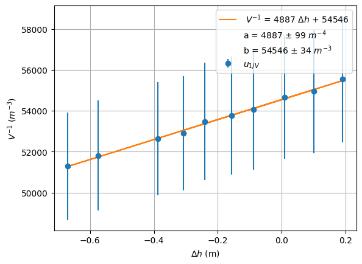

```python
#GRÁFICA

fit_y = Lineal(out.beta, dh_m)
plt.errorbar(dh_m, inv_V, yerr = u_inv_V, linestyle = 'None', marker = 'o', label = r"$u_{1/V}$")
plt.plot(dh_m, fit_y, label = r" $V^{-1}$ = 4887 $\Delta h$ + 54546")
plt.plot ([], [], ' ', label = r"a = 4887 $\pm$ 99 $m^{-4}$")
plt.plot ([], [], ' ',label = r"b = 54546 $\pm$ 34 $m^{-3}$")
plt.xlabel (r"$\Delta h$ (m)")
plt.ylabel(r"$V^{-1}$ ($m^{-3}$)")
plt.legend()
plt.grid()
plt.show()
```

```python
a = out.beta[0]
b = out.beta[1]
u_a = out.sd_beta[0]
u_b = out.sd_beta[1]

print("Parámetros del Ajuste (1/V vs Δh)")
print(f"a = {a:.0f} ± {u_a:.0f} m^-4")
print(f"b = {b:.0f} ± {u_b:.0f} m^-3\n")
```

```
Parámetros del Ajuste (1/V vs Δh)
a = 4887 ± 99 m^-4
b = 54546 ± 34 m^-3
```

### 7.3 REPRESENTACIÓN $P \cdot V$ FRENTE A MEDIDAS

```python
#AJUSTE DE DATOS LINEAL
data = RealData(i, PV_J, sy = u_PV_J)
odr = ODR(data, lin_model, beta0 = [0., 1.])
out2 = odr.run()
out2.pprint()
```

```
Beta: [-3.78512122e-04  1.89872627e+00]
Beta Std Error: [0.00046622 0.00290313]
Beta Covariance: [[ 0.00012744 -0.00070616]
 [-0.00070616  0.00494145]]
Residual Variance: 0.0017055994758884629
Inverse Condition #: 0.20922256145128448
Reason(s) for Halting:
  Sum of squares convergence
```

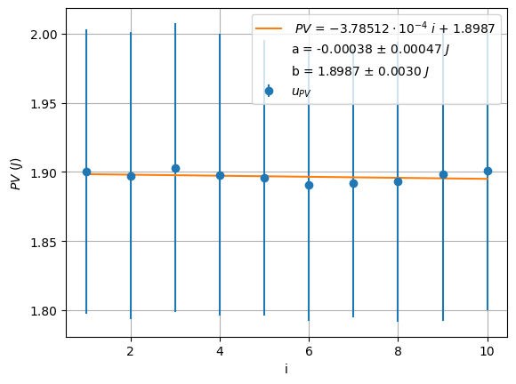

```python
#GRÁFICA

fit_y = Lineal(out2.beta, i)
plt.errorbar(i, PV_J, yerr = u_PV_J, linestyle = 'None', marker = 'o', label = r"$u_{PV}$")
plt.plot(i, fit_y, label = r" $PV$ = $-3.78512 \cdot 10^{-4}$ $i$ + 1.8987")
plt.plot ([], [], ' ', label = r"a = -0.00038 $\pm$ 0.00047 $J$")
plt.plot ([], [], ' ',label = r"b = 1.8987 $\pm$ 0.0030 $J$")
plt.xlabel (r"i")
plt.ylabel(r"$PV$ ($J$)")
plt.legend()
plt.grid()
plt.show()
```

```python
a_pv = out2.beta[0]
b_pv = out2.beta[1]
u_a_pv = out2.sd_beta[0]
u_b_pv = out2.sd_beta[1]
print("Parámetros del Ajuste (PV vs i)")
print(f"a = {a:.0f} ± {u_a:.0f} m^-4")
print(f"b = {b:.0f} ± {u_b:.0f} m^-3\n")
```

```
Parámetros del Ajuste (PV vs i)
a = 4887 ± 99 m^-4
b = 54546 ± 34 m^-3
```

```python
n = (rho_a * g) / (a * R * T_kelvin)
u_n = n * np.sqrt((u_a / a)**2 + (u_T / T_kelvin)**2)

P0_calc = b * n * R * T_kelvin
u_P0_calc = P0_calc * np.sqrt((u_n / n)**2 + (u_b / b)**2 + (u_T / T_kelvin)**2)

print(f"Número de moles (n): {n:.6f} ± {u_n:.6f} mol")
print(f"Presión del lab (P0): {P0_calc:.2f} ± {u_P0_calc:.2f} Pa")
```

```
Número de moles (n): 0.000817 ± 0.000017 mol
Presión del lab (P0): 109484.82 ± 2219.51 Pa
```